# Relatório Geral

Mozart Marinho-Jr.

22/03/2021

### Carregando os pacotes

```r
library(tidyverse)
library(googlesheets4)
library(ggthemes)
```

### Lendo a planilha de dados

A planilha está no formato google sheets, denomina-se Biomassa e a leitura é feita utilizando-se o pacote googlesheest4, fornecendo o ID da planilha. Este pode ser obtido diretamente do URL da planilha. Veja instuções no Onenote. A “sheet”Biomassa, é a segunda da planilha. O sistema pede autenticação do usuário.

```r
Biom <- read_sheet("1KkLM7bz-Az-etHUeENou-BjX4mDUfJCccwcCIo0k0CU", 2)
```

[output not shown]

[output not shown]

[output not shown]

[output not shown]

```
## Reading from "Cultivo"
```

```
## Range "'Biomassa'"
```

## Produtividade

Veremos agora, como tem se comportado a produtivade, ao longo dos anos,por ciclo de cultivo. Define-se a produtividade em kg/ha despescados em cada viveiro. E ciclo é uma rodada completa de despesca dos quatro viveiros da fazenda.

```r
Produtividade_ciclo <- Biom %>%
    group_by(ciclo) %>%# agrupa os dados por ciclo
    mutate(ciclo = factor(ciclo)) %>%
    summarize(densidade = round(mean(densidade), 2), gramatura = mean(g_final),
              produção = sum(biom_real), produtividade = round(mean(produtividade),2),
              sobrevive = round(mean(sobrevive),2)) %>%
    #filter(densidade >= 5 & sobrevive >= 50) %>% # filter após summarize,
    # sai como quqero. Omitindo  esta linha, pega totos os ciclos.
    arrange(sobrevive)

Produtividade_ciclo
```

```
## # A tibble: 23 x 6
##    ciclo densidade gramatura produção produtividade sobrevive
##    <fct>     <dbl>     <dbl>    <dbl>         <dbl>     <dbl>
##  1 12        12.4       5.65    3456.          315.      44.3
##  2 15         8.96     12.9     7150.          686.      59.2
##  3 13         8.01      7.97    4640           423.      67.8
##  4 4         13.9      11.3    11519.         1035.      69.8
##  5 11        10.7      10.2     8181           739       72.1
##  6 9         10.1       8.08    6615           591.      73.7
##  7 10         9.93     10.9     9217           834.      76.8
##  8 7         10.5       7.74    6612           668.      78.4
##  9 1         22.4       8.14   15218.         1392.      78.9
## 10 14         8.17     11.0     8240           710.      79.5
## # ... with 13 more rows
```

O gráfico abaixo, mostra a produtividade média por ciclo de cultivo, destacando-se a sobrevivência média obtida ao final da despesca, bem como a linha de corte de 1.000 kg/ha.

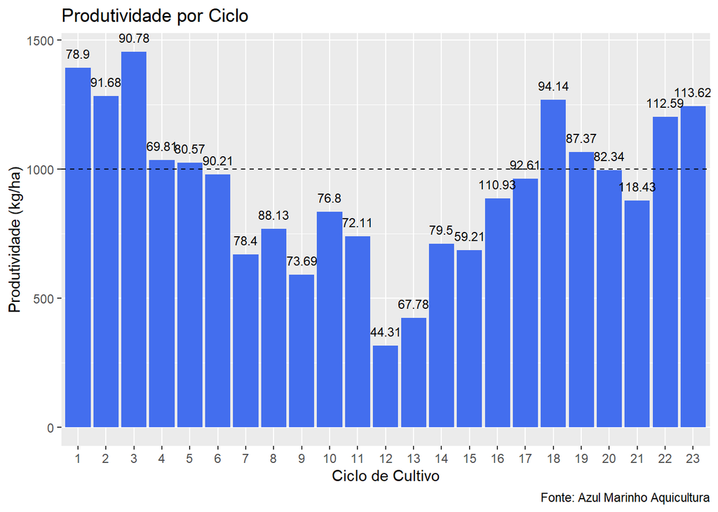

```r
Produtividade_ciclo %>%
  ggplot(aes(ciclo, produtividade)) + # Cria um ggplot object
  geom_bar(stat = "identity", fill = "royalblue2") +  # Defines the geometry
  geom_hline(yintercept = 1000, linetype="dashed", color = "black") +
  geom_text(aes(label = sobrevive), vjust = -1, color = "black", size = 3) +
  labs(title = "Produtividade por Ciclo",
         #subtitle = "Destacando a Sobrevivência Média",
         caption = "Fonte: Azul Marinho Aquicultura",
         x = "Ciclo de Cultivo",
         y = "Produtividade (kg/ha)")
```

Em média, temos obtido uma produtividade, por ciclo, de 930,30 kg/ha. No terceiro ciclo, obtivemos um máximo de 1.454,10 kg/ha. Já no ciclo de número 12, atingimos o mínimo de 315,40 kh/ha devido a ocorrência do vírus da mancha branca. Estabelecemos como valor de corte, 1.000 kh/ha, que nem sempre foi alcançado devido à variáveis como densidade de estocagem, mortalidade, tempo de cultivo e peso médio do camarão despescado.

### Produtividade por Viveiro

Em méida, os viveiros povoados com 14 $camarões/m^{2}$ superam a produtividade de 1000 kh/ha. Nestes o período médio de cultivo é de 80 dias para camarões de 9,23g.

Quando os números de produtivida são mostrados separadps para cada um dos quatro viveiros, observamos que a distribuição, em geral, segue o mesmo padrão. As produtividades maiores estão nos primeiros e nos últimos ciclos. Nos primeiros, trabalhamos com densidades maiores, e a queda, em seguida, foi resultante de uma diminuição das desnsidades e da incidência da mancha branca. Já nos últios ciclos, procuramos trabalhar com densidades mais elevadas. Houve diminuição apenas no primeiro semestre de 2020, nos primeiros meses da pandemia de Covid-19.

```r
Produtividade_viveiro_ciclo <- Biom %>%
  #filter(densidade >= 10 & sobrevive >= 50) %>% # neste caso, o filtro opera
  #antes de summarize e não é o desejado
  group_by(viveiro, ciclo) %>%# agrupa os dados
  mutate(ciclo = factor(ciclo), viveiro = factor(viveiro)) %>%
  summarize(densidade = round(mean(densidade), 2), gramatura = mean(g_final),
            produção = sum(biom_real), produtividade = round(mean(produtividade),2),
            sobrevive = round(mean(sobrevive),2), ddc = mean(ddc)) %>%
  #filter(densidade >= 5 & sobrevive >= 50) %>% # filter após summarize,
  # sai como quqero. Omitindo  esta linha, pega totos os ciclos.
  arrange(sobrevive)
Produtividade_viveiro_ciclo
```

```
## # A tibble: 91 x 8
## # Groups:   viveiro [4]
##    viveiro ciclo densidade gramatura produção produtividade sobrevive   ddc
##    <fct>   <fct>     <dbl>     <dbl>    <dbl>         <dbl>     <dbl> <dbl>
##  1 2       12        12.6       4.92     446           137.      25.4    44
##  2 3       12        12.0       5.05     867.          215.      35.4    46
##  3 1       12        12.5       5.5      274           236.      39.8    43
##  4 3       7         10         6.41    1145           294.      45.8    49
##  5 4       15         8.9      16.1     1935           663.      46.2    80
##  6 3       15         8.97      8.27    1358.          348.      46.9    64
##  7 3       4         13.8      14.0     3828.          982.      50.8    95
##  8 3       13         8        10.3     1663           426.      51.9    61
##  9 1       11        10.3      12.6      795           685.      52.6    67
## 10 4       13         8.01      7.15     936           321.      55.9    56
## # ... with 81 more rows
```

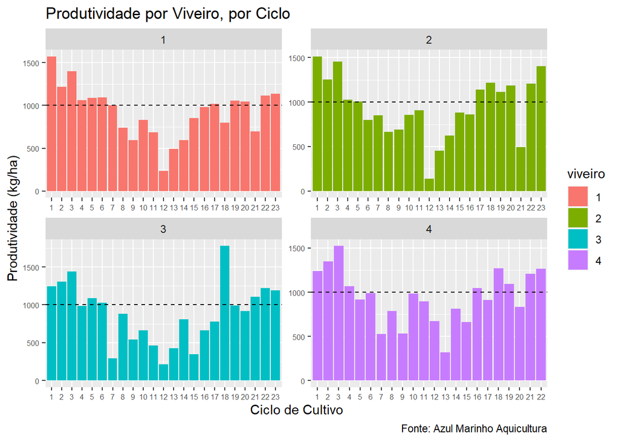

```r
Produtividade_viveiro_ciclo %>%
  ggplot(aes(ciclo, produtividade, fill = viveiro)) + # Cria um ggplot object
  geom_col() +  # Defines the geometry
  geom_hline(yintercept = 1000, linetype="dashed", color = "black") +
  #geom_text(aes(label = sobrevive),
   #         vjust = -0.25,
   #         color = "black", size = 3,
   #          position = position_dodge(width = 0.9),
   #          check_overlap = TRUE) +
  facet_wrap(~ viveiro, scales = "free") +
  theme(axis.text = element_text(size = 6))+ # diminui a fonte para melhor visualização no pdf.
  labs(title = "Produtividade por Viveiro, por Ciclo",
       #subtitle = "Destacando a Sobrevivência Média",
       caption = "Fonte: Azul Marinho Aquicultura",
       x = "Ciclo de Cultivo",
       y = "Produtividade (kg/ha)")
```

```r
Produtividade_mil <- Biom %>%
  #filter(densidade >= 10 & sobrevive >= 50) %>% # neste caso, o filtro opera
  #antes de summarize e não é o desejado
  filter(produtividade >= 1000) %>%
group_by(viveiro, ciclo) %>%# agrupa os dados
  mutate(ciclo = factor(ciclo), viveiro = factor(viveiro)) %>%
  summarize(densidade = round(mean(densidade), 2), gramatura = mean(g_final),
            produção = sum(biom_real), produtividade = round(mean(produtividade),2),
            sobrevive = round(mean(sobrevive),2), ddc = mean(ddc)) %>%
  #filter(densidade >= 5 & sobrevive >= 50) %>% # filter após summarize,
  # sai como quqero. Omitindo  esta linha, pega totos os ciclos.
  arrange(sobrevive)
Produtividade_mil %>%
  select(produtividade, densidade) %>%
  summarise(densidade)
```

```
## # A tibble: 41 x 2
## # Groups:   viveiro [4]
##    viveiro densidade
##    <fct>       <dbl>
##  1 1            15
##  2 1            23.7
##  3 1            13.8
##  4 1            13.8
##  5 1            13.8
##  6 1            12.1
##  7 1            12.1
##  8 1            15.1
##  9 1            14.2
## 10 1            13.8
## # ... with 31 more rows
```

```r
summary(Produtividade_mil)
```

```
##  viveiro     ciclo      densidade       gramatura         produção
##  1:12    1      : 4   Min.   : 8.90   Min.   : 6.610   Min.   : 990
##  2:11    2      : 4   1st Qu.:13.79   1st Qu.: 8.050   1st Qu.:1620
##  3: 9    3      : 4   Median :13.85   Median : 9.330   Median :3698
##  4: 9    22     : 4   Mean   :14.42   Mean   : 9.227   Mean   :3291
##          4      : 3   3rd Qu.:15.00   3rd Qu.:10.530   3rd Qu.:4321
##          5      : 3   Max.   :25.23   Max.   :12.510   Max.   :5608
##          (Other):19
##  produtividade    sobrevive           ddc
##  Min.   :1002   Min.   : 68.20   Min.   : 52.00
##  1st Qu.:1086   1st Qu.: 85.18   1st Qu.: 72.00
##  Median :1190   Median : 96.22   Median : 82.00
##  Mean   :1215   Mean   : 94.35   Mean   : 80.07
##  3rd Qu.:1271   3rd Qu.:101.59   3rd Qu.: 89.00
##  Max.   :1779   Max.   :134.70   Max.   :108.00
##
```